# Geostatistics for UKCP18 JULES input data

13/09/2024

## Outline

- Nonstationary geostatistics
  - UKCP18 data examples
  - Illustrations of nonstationary covariance
  - Simulations
- Projecting UKCP18 under different SSPs

## Conditioning on different RCPs

## Daily max temperatures

- UKCP18 12km data for the UK for `tasmax` and RCP8.5 for ‘July’ 2070.

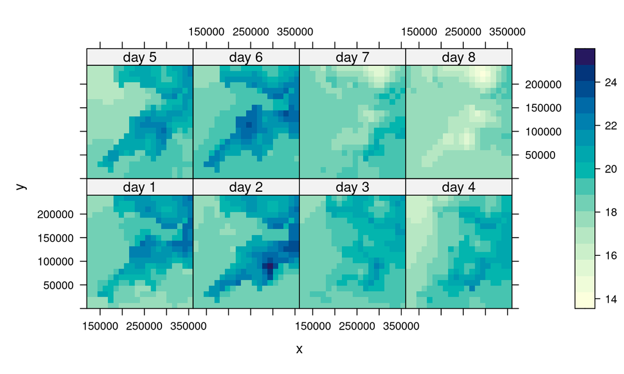

## 60km daily max temperatures

- The 60km UKCP18 data also gives `tasmax`

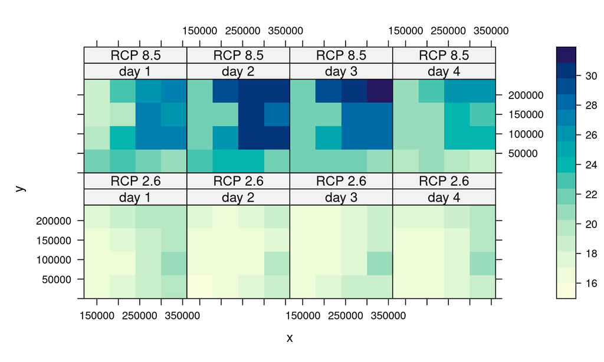

… but the days don’t match up

## Statistical 12km model

- We can build a statistical model that mimics the 12km data and simulate from it

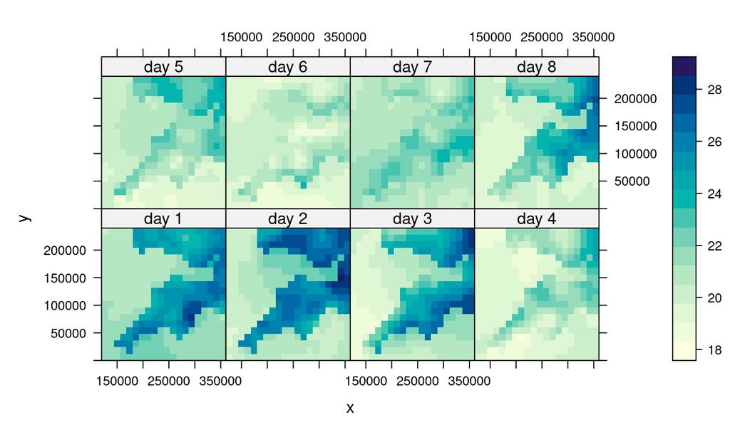

- and can further downscale to parcel level using Jonathan and Ilya’s `mesoclim` `R` package

## Statistical 12km model

- We can constrain the statistical model too
  - here the average is 20\(^\circ\)C over the domain

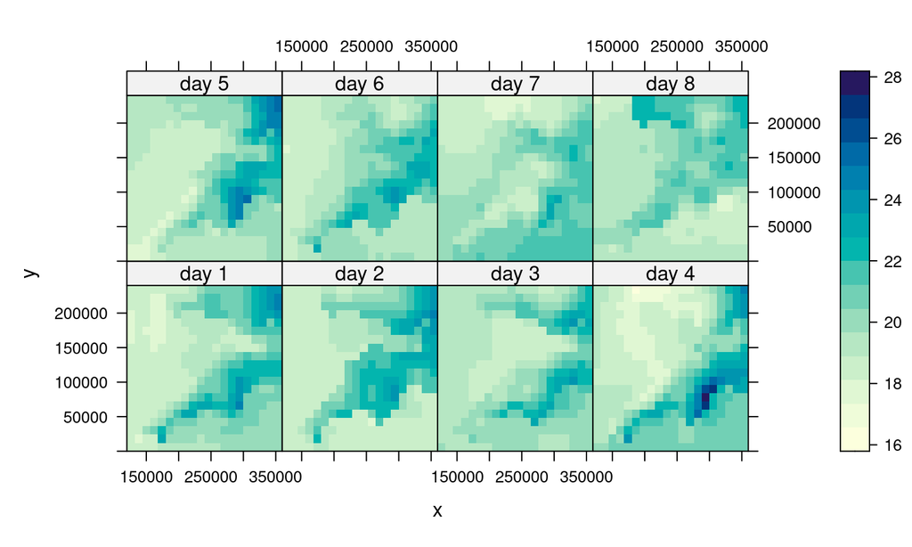

- which looks okay, but the day 4 range looks a little high

## Statistical 12km model constrained by 60km model

- We can also constrain the statistical model with the average of the 60km model

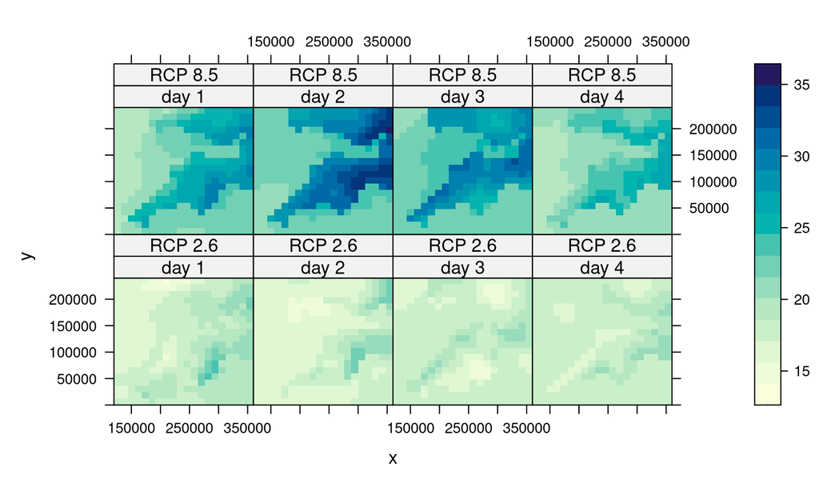

## Averaging over ensemble members

- If we now average over ensemble members and over 2070-2079, we can look at the mean difference of RCP8.5 - RCP2.6

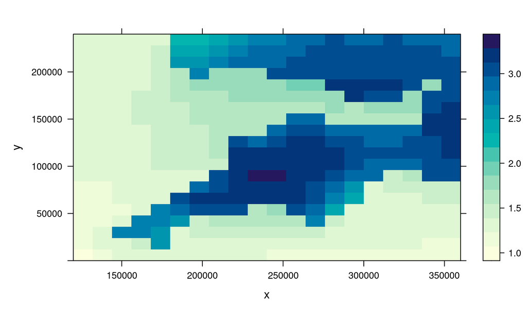

## Mean difference for 60km

- which is consistent with the mean difference in the original 60km data

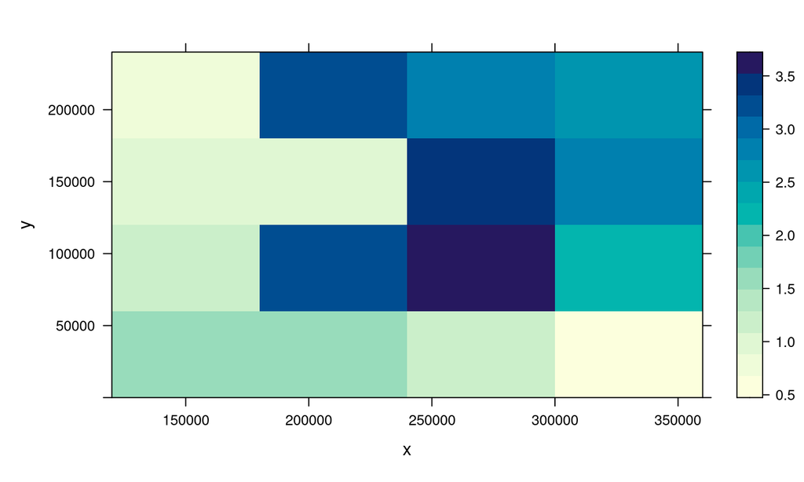

## Using CMIP to give different SSP data

- Mean July temperature over South West for 3 ensemble members per SSPs using CSIRO’s ACCESS-CM2 model

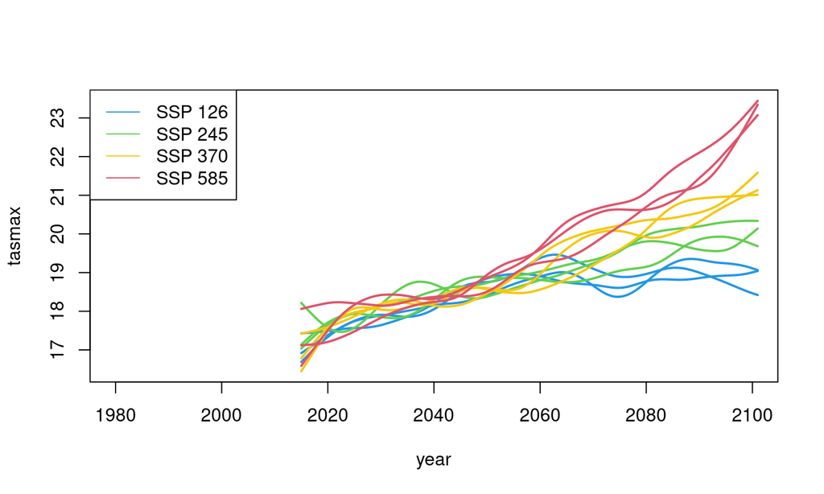

## CMIP vs UKCP18

- We can see how UCKP18’s RCP8.5 compares…

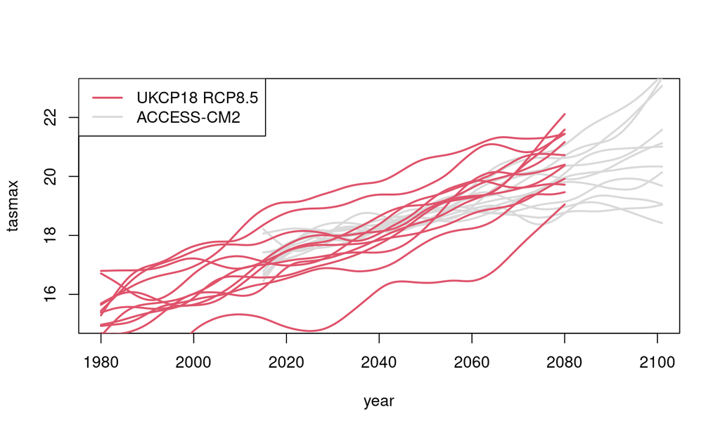

- … and it looks like it has a bit more spread

## Simulation given CSIRO projections

- We can simulate from our 12km model, so that the daily average match CMIP6’s, for the same region
- And the overall temperature averages look rather sensible

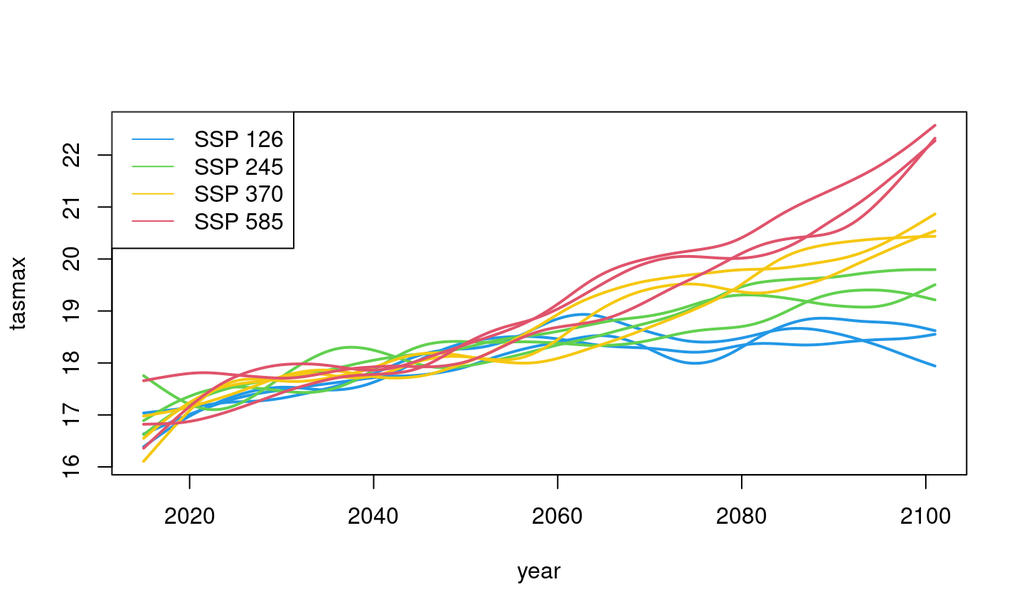

## Precipitation

## Precip in CMIP: January

- We can also get CMIP6 precipitation projections from CSIRO’s ACCESS-CSM2 model

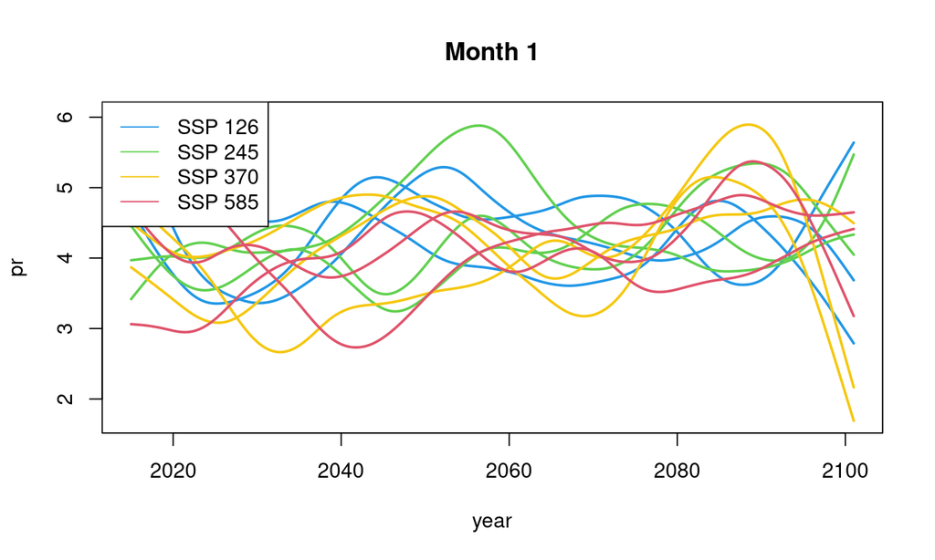

… which show less clear (if any) SSP separation

## Precip in CMIP: April

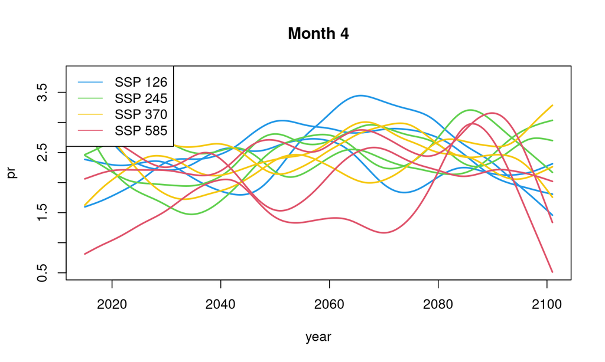

## Precip in CMIP: July

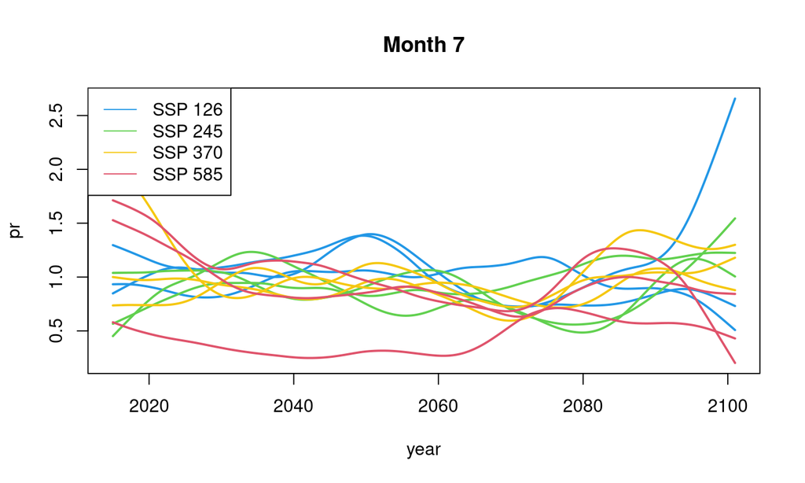

## Precip in CMIP: October

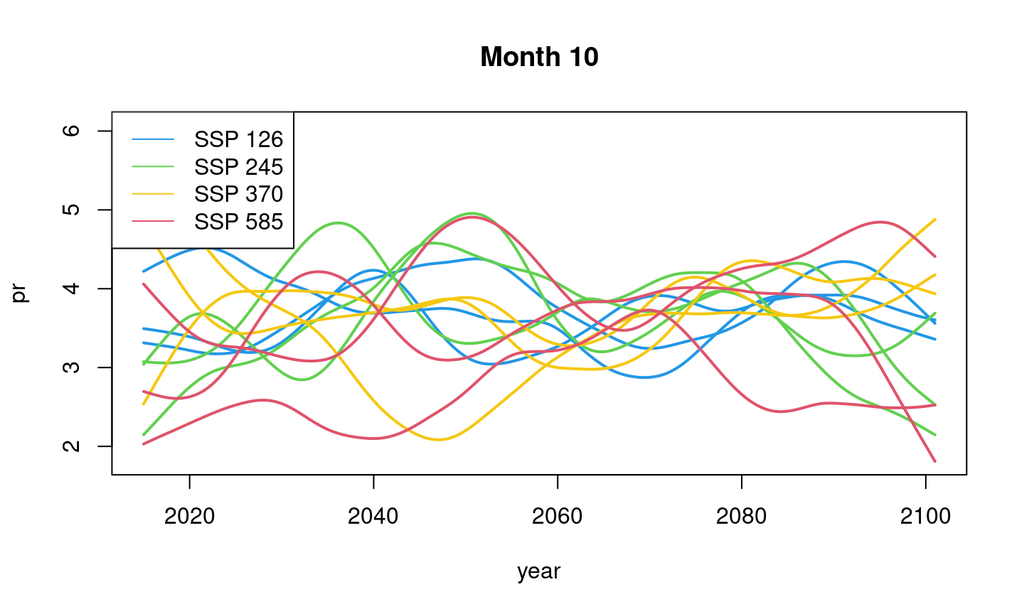

## Gaussian models for precipitation

- At a given location the distribution is very non-Gaussian

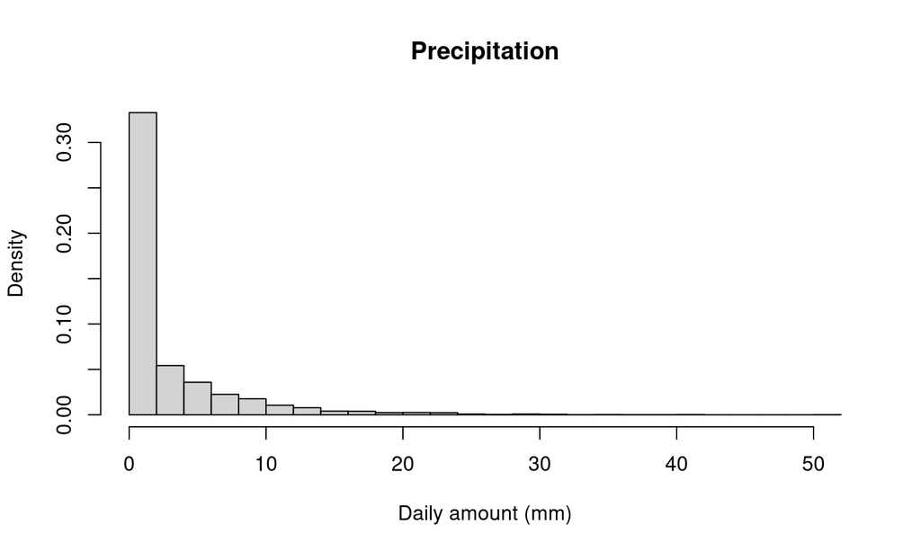

## Gaussian models for precipitation

- A censored model isn’t good enough, if we’re interested in any rainfall amount

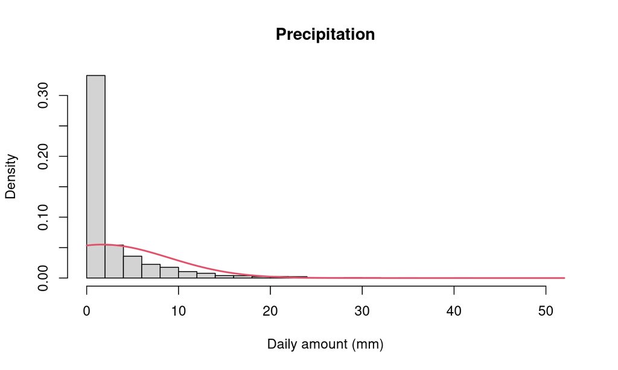

## Precipitation for UKCP18 projections given CSIRO projections for July

- We can simulate 12km data that aggregate to match the CSIRO precipitation predictions

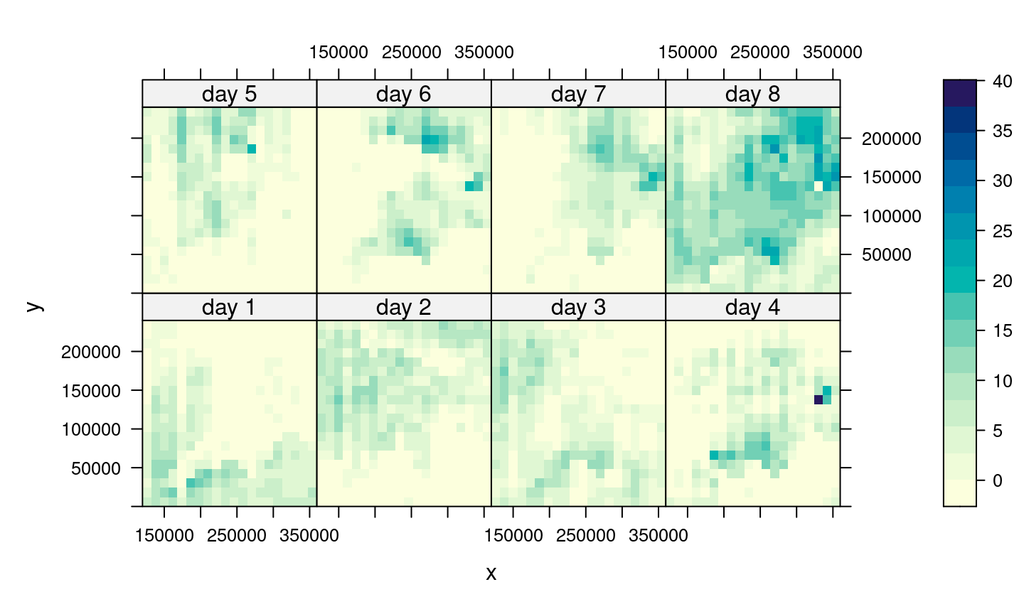

… but the actual rainfall model needs refining a bit

## Precipitation for UKCP18 projections given CSIRO projections for July

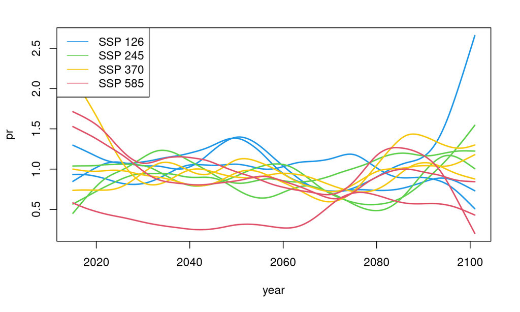

## sfcWind

## sfcWind in CMIP: October

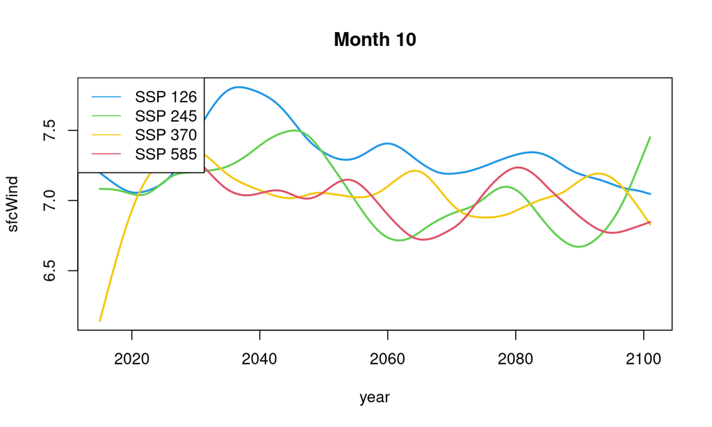

## sfcWind for UKCP18 projections given CSIRO projections for October

- We can use a Gaussian model to simulate `sfcWind` given CMIP6’s averages

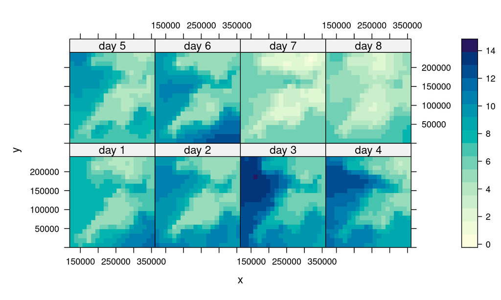

## sfcWind for UKCP18 projections given CSIRO projections for October

- The averages match up

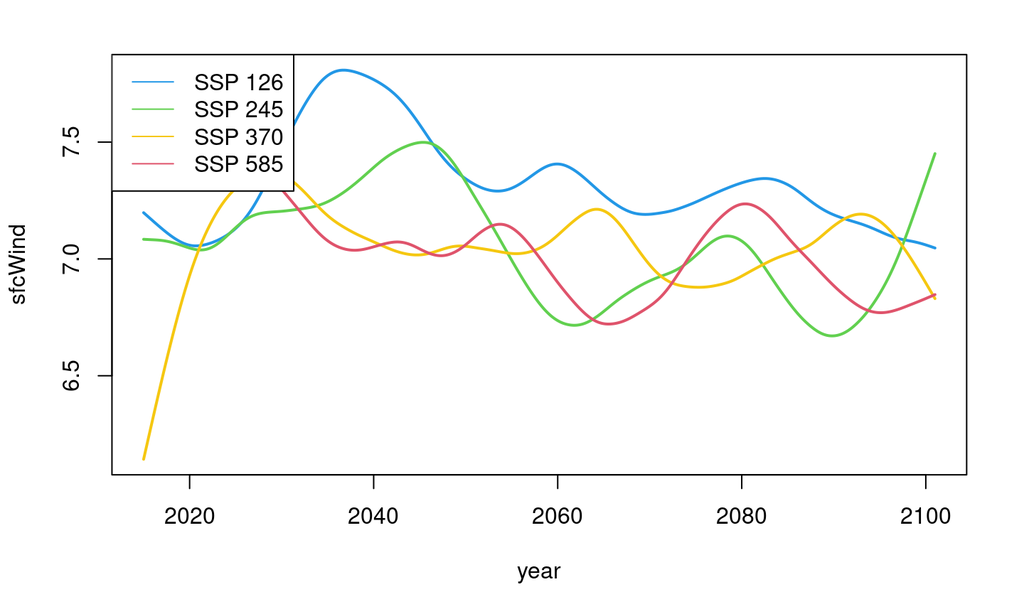

## A Gaussian model for wind speeds isn’t accurate enough

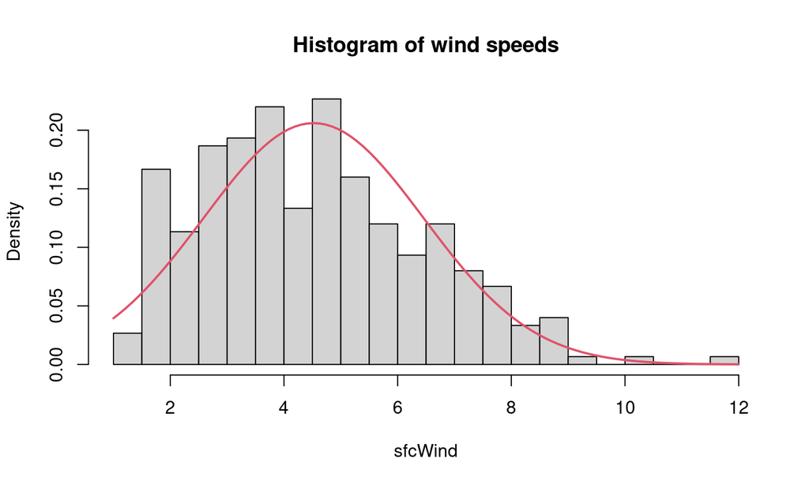

## A Gaussian model for wind speeds isn’t accurate enough

- …a Weibull model is more appropriate

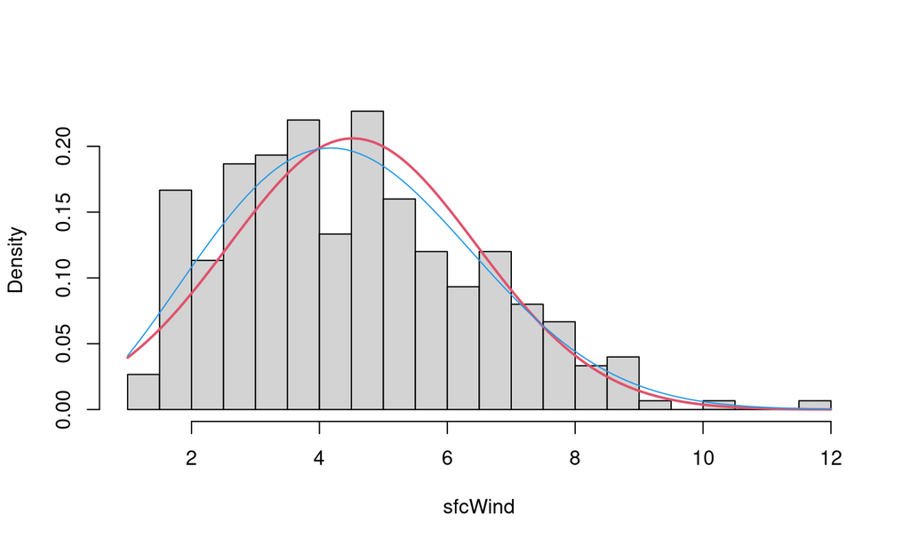

## Gaussian anamorphosis

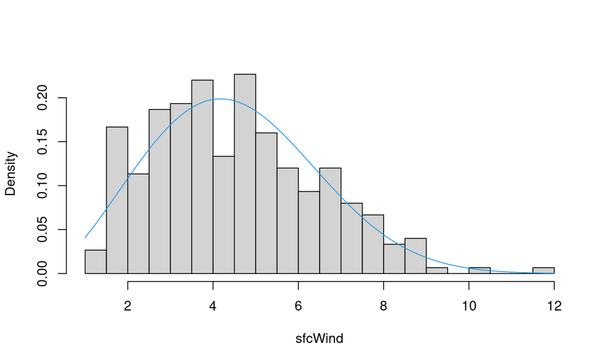

## Gaussian anamorphosis

- The Weibull model lets us transform things to being uniform

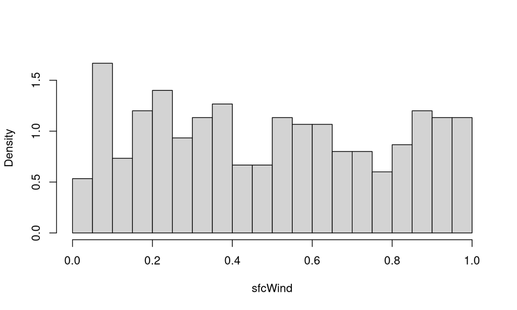

## Gaussian anamorphosis

- …or to anything, such as Gaussian(ish)

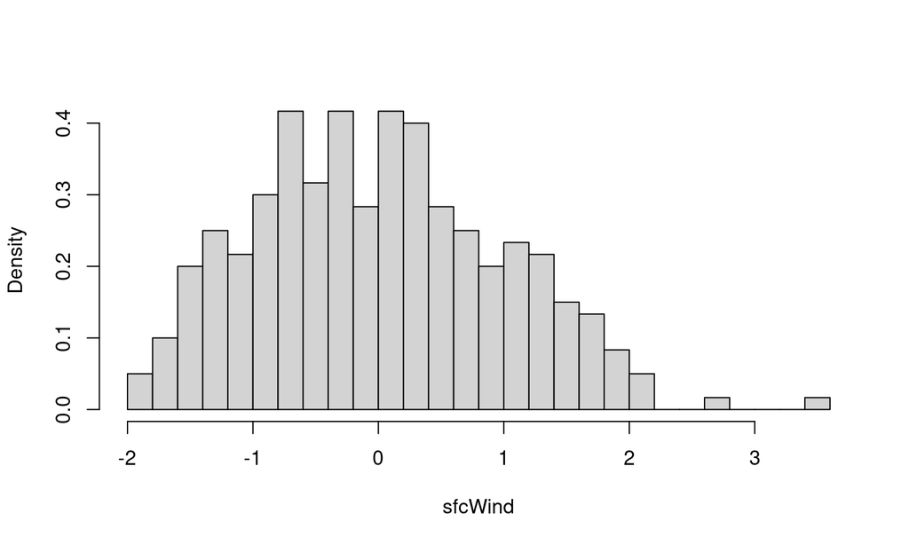

## sfcWind conversions between statistical model and CMIP6

- Then we need to convert mean wind speeds between original and transformed scales, so we can condition on mean values from CMIP6

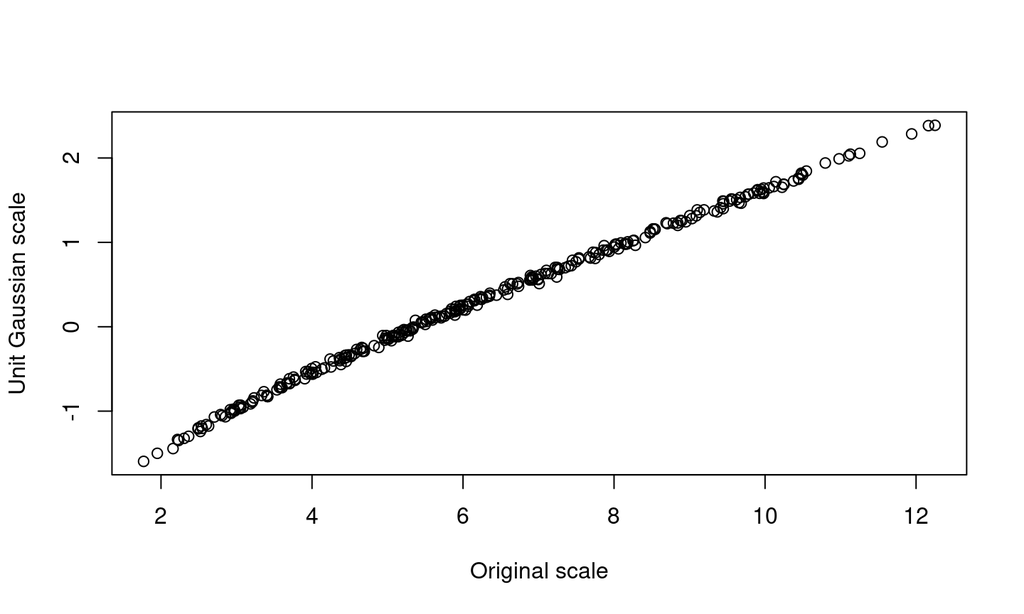

## sfcWind conversions between statistical model and CMIP6

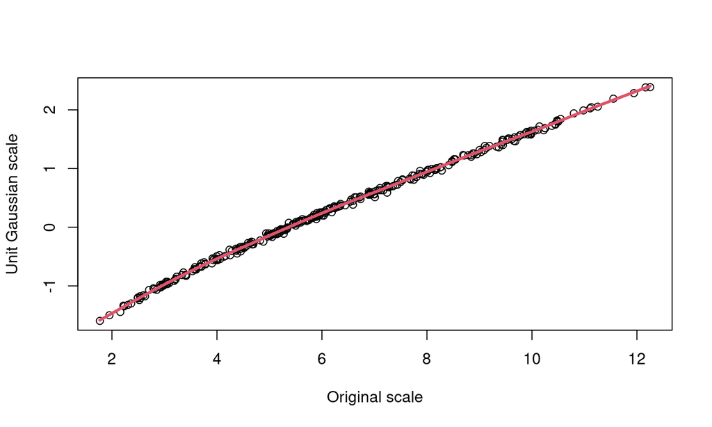

## sfcWind simulations

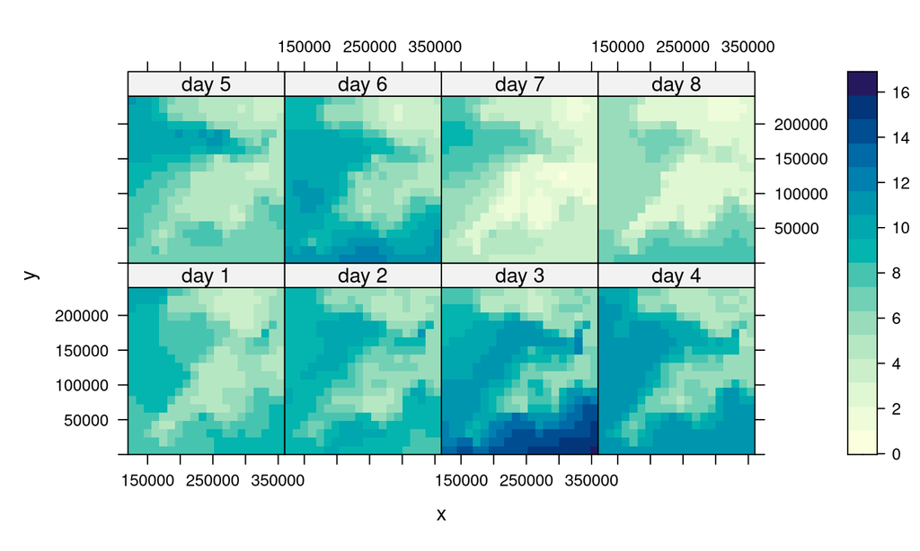

## Wind speed simulations given CMIP6

- Aggregated simulated wind speeds are consistent with the CMIP6 conditioning data

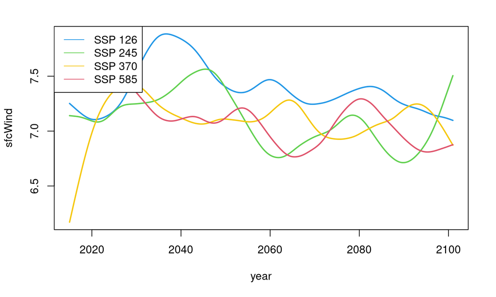

## In summary

- Statistical models for UKCP18’s 12km output seem to mimic the output well
- Conditional simulations also seem to give sensible temperatures
- CMIP6’s ScenarioMIP via CSIRO’s ACCESS-CSM2 output gives temperatures consistent with UKCP18’s for RCP8.5
- Conditional simulations using CMIP6 captures its trends
- Models for precipitation and wind speeds also seem to work, but need some refinement

## Questions?

- If we do things separately by month, how do we make coherent transitions between months?
- How do we also ensure day-to-day consistency?
- Are these important, as we’re looking as tree growth over ~60 years, and are conditioning on coherent data?